# Exploratory Data Analysis

[figure not shown]

## **Exploratory Data Analysis** **© Mehdi Rezvandehy**

Summary

This notebook presents different approaches for exploratory data analysis and basic statistical analysis. Python functions are written to make nice data visualization including histogram, CDF, swarm plot, box plot, Violin plot, Kernel Density Estimation, cross plot and correlation. Probability distribution including binomial PMF, Poisson, Normal and Exponential distribution will be discussed. Finally data manipulation and data analysis with Pandas will be presented.

Python functions and data files to run this notebook are in my [Github](https://github.com/MehdiRezvandehy/Exploratory_Data_Analysis.git) page.

```python
import pandas as pd
import numpy as np
import seaborn as sns
import matplotlib
import pylab as plt
from functions import* # import require functions to run this notebook
import warnings
warnings.filterwarnings('ignore')
```

# Data Visualization

The data is 2008 US swing state election results downloaded from https://www.kaggle.com/datasets/aman1py/swing-states?resource=download

```python
df_swing=pd.read_csv('./Data/2008_swing_states.csv')
df_swing[['state','county','dem_share']][:5]
```

|  | state | county | dem_share |
| --- | --- | --- | --- |
| 0 | PA | Erie County | 60.08 |
| 1 | PA | Bradford County | 40.64 |
| 2 | PA | Tioga County | 36.07 |
| 3 | PA | McKean County | 41.21 |
| 4 | PA | Potter County | 31.04 |

## Histogram

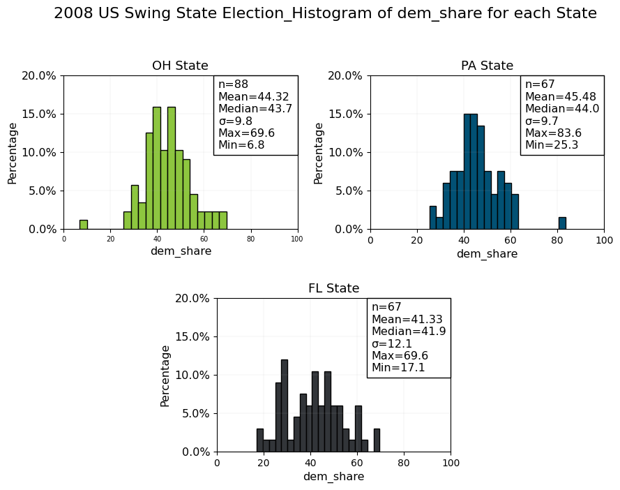

```python
font = {'size'   : 7}
plt.rc('font', **font)
fig, ax1 = plt.subplots(figsize=(10, 7), dpi= 100, facecolor='w', edgecolor='k')

gs = gridspec.GridSpec(2, 4)
ax1=plt.subplot(gs[0, :2], )
KPI='dem_share'
val=df_swing[df_swing['state']=='OH'][KPI]
EDA_plot.histplt (val,bins=20,title='OH State',xlabl=KPI,
         ylabl='Percentage',xlimt=(0,100),ylimt=(0,0.2),axt=ax1,
         scale=1.15,loc=1,font=10,color='#8DC63F')

ax2=plt.subplot(gs[0, 2:])
KPI='dem_share'
val=df_swing[df_swing['state']=='PA'][KPI]
EDA_plot.histplt (val,bins=20,title='PA State',xlabl=KPI,
         ylabl='Percentage',xlimt=(0,100),ylimt=(0,0.2),axt=ax2,
         scale=1.15,loc=1,font=10,color='#025174')

ax3=plt.subplot(gs[1, 1:3])
val=df_swing[df_swing['state']=='FL'][KPI]
EDA_plot.histplt (val,bins=20,title='FL State',xlabl=KPI,
         ylabl='Percentage',xlimt=(0,100),ylimt=(0,0.2),axt=ax3
         ,scale=1.15,loc=1,font=10,color='#323539')

plt.subplots_adjust(wspace=0.9)
plt.subplots_adjust(hspace=0.45)
fig.suptitle('2008 US Swing State Election_Histogram of dem_share for each State', fontsize=16,y=1.02)

plt.show()
```

## Bee Swarm plot

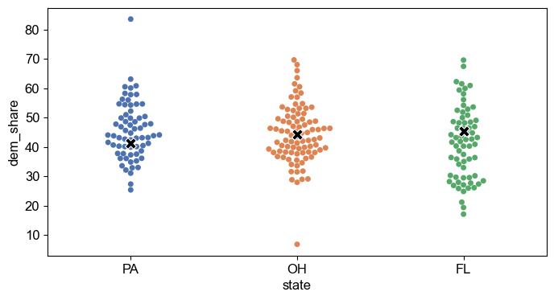

```python
font = {'size'   : 12}
plt.rc('font', **font)
fig, ax1 = plt.subplots(figsize=(8, 4), dpi= 100, facecolor='w', edgecolor='k')


sns.set_theme(style="whitegrid")
tips = sns.load_dataset("tips")
ax = sns.swarmplot(x="state", y="dem_share", data=df_swing)
df_means = df_swing.groupby("state")["dem_share"].agg("mean").reset_index()
xlim = ax.get_xlim()
ylim = ax.get_ylim()
sns.scatterplot(x="state", y="dem_share", marker='X', color='black',
                s=100, zorder=3, ax=ax, legend=True, data=df_means)
ax.set_xlim(xlim)
ax.set_ylim(ylim)
plt.show()
```

## Box Plot

The center of box plot is 50th percentile which has a higher limit of 75th percentile and lower limit of 25th percentile. This is called IQR (Interquartile Range). The reset extend of data is 1.5 IQR.

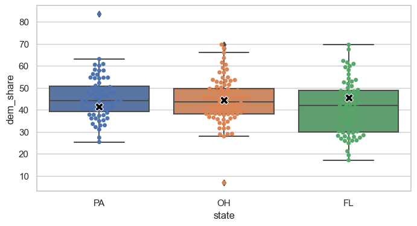

```python
font = {'size'   : 7}
plt.rc('font', **font)
fig, ax1 = plt.subplots(figsize=(8, 4), dpi= 100, facecolor='w', edgecolor='k')


sns.set_theme(style="whitegrid")
tips = sns.load_dataset("tips")
ax = sns.swarmplot(x="state", y="dem_share", data=df_swing)
ax = sns.boxplot(x="state", y="dem_share", data=df_swing)
df_means = df_swing.groupby("state")["dem_share"].agg("mean").reset_index()
xlim = ax.get_xlim()
ylim = ax.get_ylim()
sns.scatterplot(x="state", y="dem_share", marker='X', color='black',
                s=100, zorder=3, ax=ax, legend=True, data=df_means)
ax.set_xlim(xlim)
ax.set_ylim(ylim)
plt.show()
```

## Violin Plot

```python
#plt.style.available
plt.style.use('classic')
```

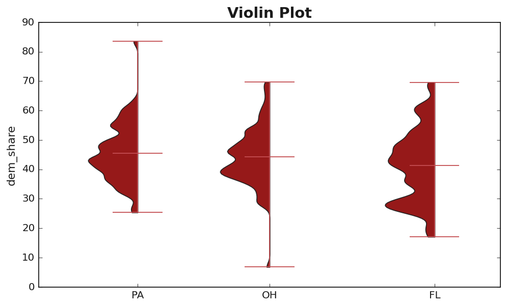

```python
KPI='dem_share'
val=[]
val.append(np.array(df_swing[df_swing['state']=='PA'][KPI]))
val.append(np.array(df_swing[df_swing['state']=='OH'][KPI]))
val.append(np.array(df_swing[df_swing['state']=='FL'][KPI]))
#
Position=[100,500,1000]

font = {'size'   : 11}
plt.rc('font', **font)
fig, ax1 = plt.subplots(figsize=(9, 5), dpi= 130, facecolor='w', edgecolor='k')

v1 = plt.violinplot(val, points=100, positions=Position, widths=300,
               showmeans=True,showextrema=True, showmedians=False,bw_method =0.15)
for b in v1['bodies']:
    m = np.mean(b.get_paths()[0].vertices[:, 0])
    b.get_paths()[0].vertices[:, 0] = np.clip(b.get_paths()[0].vertices[:, 0], -np.inf, m)
    b.set_color('darkred')
    b.set_edgecolor('k')
    b.set_linewidth(1)
    b.set_alpha(0.9)
#plt.axis('off')
plt.ylabel('dem_share',fontsize=12)

plt.xticks([100,500,1000],['PA','OH','FL'],rotation=0)
plt.title("Violin Plot",fontweight="bold",fontsize=16)
plt.show()
```

## Kernel Density Estimation

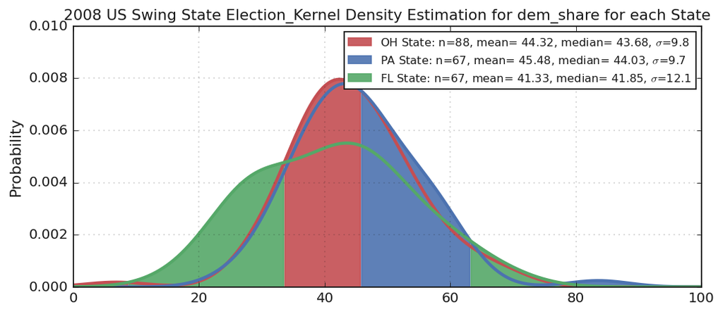

```python
font = {'size'   : 11}
plt.rc('font', **font)
fig, ax1 = plt.subplots(figsize=(9, 8), dpi= 130, facecolor='w', edgecolor='k')

ax1=plt.subplot(2,1,1)
label=['OH State','PA State','FL State']

data_var=len(label)*[None]
KPI='dem_share'
data_var[0]=np.array(df_swing[df_swing['state']=='OH'][KPI])
data_var[1]=np.array(df_swing[df_swing['state']=='PA'][KPI])
data_var[2]=np.array(df_swing[df_swing['state']=='FL'][KPI])

nvar=3
xs = np.linspace(0,100,500)
colors = ['r','b','g']
title='2008 US Swing State Election_Kernel Density Estimation for dem_share for each State'
EDA_plot.KDE(xs,data_var,nvar,label,colors,xlabel=None,title=title,ylabel='Probability',xlim=(0,100),ylim=(0,0.01),
    LAMBA=0.5,linewidth=2.5,loc=0,axt=ax1,x_ftze=12,y_ftze=12,tit_ftze=12,leg_ftze=9)
```

## Emperical cdf

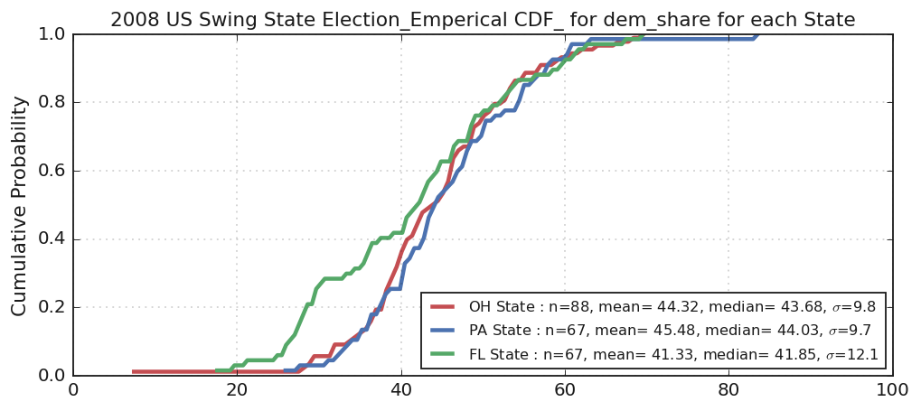

```python
font = {'size'   : 11}
plt.rc('font', **font)
fig, ax1 = plt.subplots(figsize=(9, 8), dpi= 130, facecolor='w', edgecolor='k')

label=['OH State','PA State','FL State']

data_var=len(label)*[None]
KPI='dem_share'
data_var[0]=np.array(df_swing[df_swing['state']=='OH'][KPI])
data_var[1]=np.array(df_swing[df_swing['state']=='PA'][KPI])
data_var[2]=np.array(df_swing[df_swing['state']=='FL'][KPI])

ax1=plt.subplot(2,1,1)
title=f'2008 US Swing State Election_Emperical CDF_ for dem_share for each State'
EDA_plot.CDF_plot(data_var,nvar,label,colors,xlabel=None,title=title,ylabel='Cumulative Probability',bins=100,
    xlim=(0,100),ylim=(0,1),linewidth=2.5,loc=0,axt=ax1,x_ftze=12,y_ftze=12,tit_ftze=12,leg_ftze=9)

plt.show()
```

## Percentile

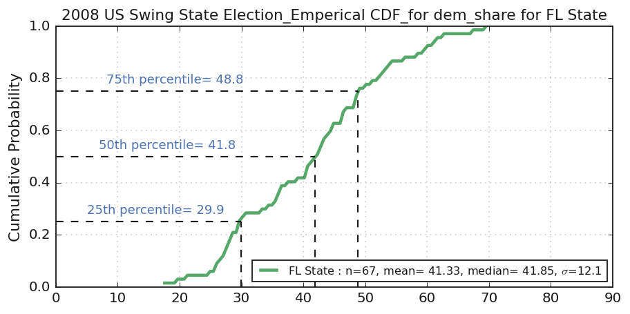

```python
font = {'size'   : 11}
plt.rc('font', **font)
fig, ax1 = plt.subplots(figsize=(8, 8), dpi= 130, facecolor='w', edgecolor='k')

label=['FL State']
KPI='dem_share'
data_var=np.array(df_swing[df_swing['state']=='FL'][KPI])

ax1=plt.subplot(2,1,1)
title=f'2008 US Swing State Election_Emperical CDF_for dem_share for FL State'
EDA_plot.CDF_plot(data_var,1,label,colors='g',xlabel=None,title=title,ylabel='Cumulative Probability',bins=100,
    xlim=(0,90),ylim=(0,1),linewidth=2.5,loc=4,axt=ax1,x_ftze=12,y_ftze=12,tit_ftze=12,leg_ftze=9)

# 25th percentile
per=0.25
Perctile=np.quantile(data_var, per, axis=0, keepdims=True)[0]
txt= '25th percentile= '
txt+=f'{np.round(Perctile,1)}'
plt.plot([0, Perctile], [per, per], 'k--', linewidth=1.2)
plt.plot([Perctile, Perctile], [0, per], 'k--', linewidth=1.2)
plt.text(Perctile/6, per+0.03, txt, color='b',
         fontsize=10)

# 50th percentile
per=0.5
Perctile=np.quantile(data_var, per, axis=0, keepdims=True)[0]
txt= '50th percentile= '
txt+=f'{np.round(Perctile,1)}'
plt.plot([0, Perctile], [per, per], 'k--', linewidth=1.2)
plt.plot([Perctile, Perctile], [0, per], 'k--', linewidth=1.2)
plt.text(Perctile/6, per+0.03, txt, color='b',
         fontsize=10)

# 75th percentile
per=0.75
Perctile=np.quantile(data_var, per, axis=0, keepdims=True)[0]
txt= '75th percentile= '
txt+=f'{np.round(Perctile,1)}'
plt.plot([0, Perctile], [per, per], 'k--', linewidth=1.2)
plt.plot([Perctile, Perctile], [0, per], 'k--', linewidth=1.2)
plt.text(Perctile/6, per+0.03, txt, color='b',
         fontsize=10)

plt.show()
```

## Cross plot

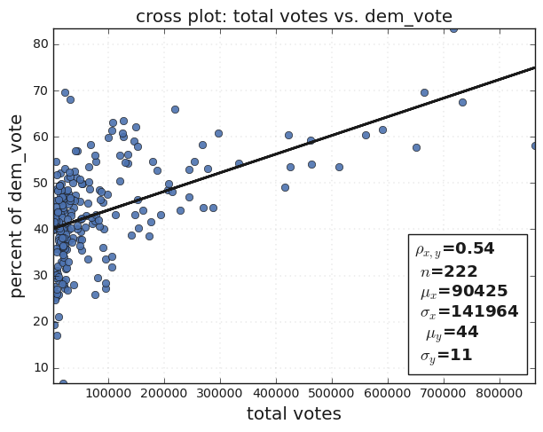

```python
font = {'size'   : 12}
plt.rc('font', **font)
fig, ax1 = plt.subplots(figsize=(7, 5), dpi= 100, facecolor='w', edgecolor='k')


x=df_swing['total_votes']
y=df_swing['dem_share']
EDA_plot.CrossPlot(x,y,title='cross plot: total votes vs. dem_vote',
          xlabl='total votes',ylabl='percent of dem_vote',loc=1,xlimt=(np.nanmin(x),np.nanmax(x)),
          ylimt=(np.nanmin(y),np.nanmax(y)),axt=ax1,scale=1.2,alpha=0.9,markersize=6,marker='bo',font=font)
```

## Correlation

Synthetic data with 6 features, Var1 to Var6 with Gaussian, Triangular and Uniform distribution are generated to have linear and non-linear correlation with target for 100000 data.

```python
# Generate synthetic data
df=quadrac_swiss_roll(noise=2,nsim=100000,time_rand1=1,seed=42,a1=20,b1=8,a2=50,b2=8,swiss_roll=True)
features_colums=df.columns
# Satndardize data
for i in df.columns:
    df[i] = zscore(df[i])
```

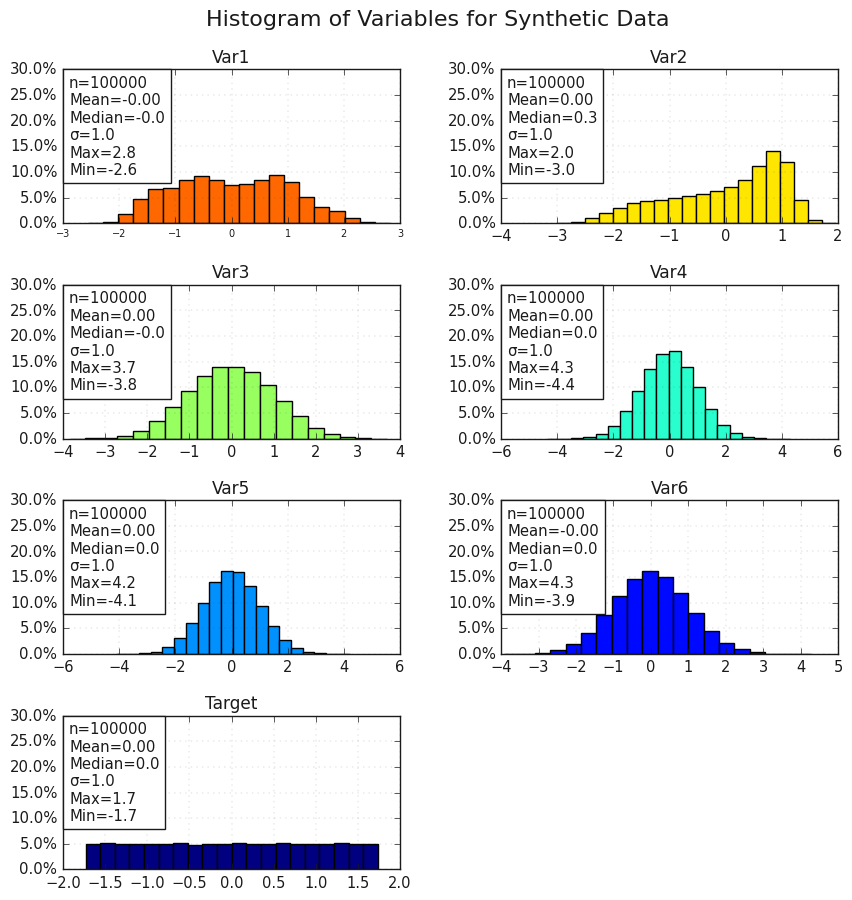

```python
font = {'size'   : 7}
plt.rc('font', **font)
fig, ax1 = plt.subplots(figsize=(10, 10), dpi= 100, facecolor='w', edgecolor='k')
colors_map = plt.cm.get_cmap('jet')

colors = colors_map(np.linspace(0,0.8,len(features_colums)))

for ir in range(len(features_colums)):
    ax1=plt.subplot(4,2,ir+1)
    val=df[features_colums[ir]]

    EDA_plot.histplt(val,bins=20,title=f'{features_colums[ir]}',xlabl=None,days=False,
             ylabl=None,xlimt=None,ylimt=(0,0.3)
             ,axt=ax1,nsplit=5,scale=1.02,loc=2,font=10.5,color=colors[len(features_colums)-ir-1])
plt.subplots_adjust(hspace=0.4)
plt.subplots_adjust(wspace=0.3)
fig.suptitle(f'Histogram of Variables for Synthetic Data', fontsize=16,y=0.96)
plt.show()
```

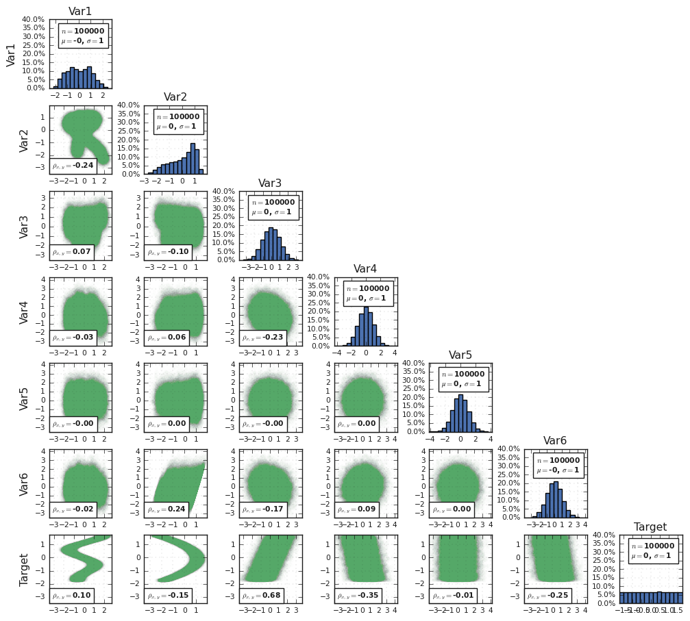

```python
font = {'size'   :9 }
plt.rc('font', **font)

fig=plt.figure(figsize=(10, 9), dpi= 100, facecolor='w', edgecolor='k')
# Satndardize data
for i in features_colums:
    df[i] = zscore(df[i])
cplotmatrix(df,font=font,alpha=0.008,marker='g.',missin_rep=False)
plt.show()
```

Correlation Coefficient

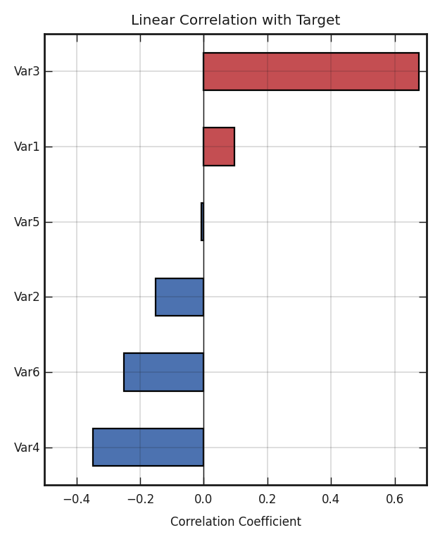

```python
font = {'size'   : 6}
plt.rc('font', **font)
fig, ax1 = plt.subplots(figsize=(3.5, 4), dpi= 200, facecolor='w', edgecolor='k')

corr=df.corr()
corr=corr['Target'].drop(['Target'])
coefs=corr.values
features_colums=list(corr.index)
Correlation_plot.corr_bar(coefs,clmns=features_colums,select=False,yfontsize=6.0,title=f'Linear Correlation with Target',
                          ymax_vert_lin=30,xlim = [-0.5, 0.7])
```

Coefficient of Determination

There are multiple Formulas to calculate the coefficient of determination. It can be simply calculated from correlation coefficient:

**Coefficient of Determination=(Correlation Coefficient)^2**

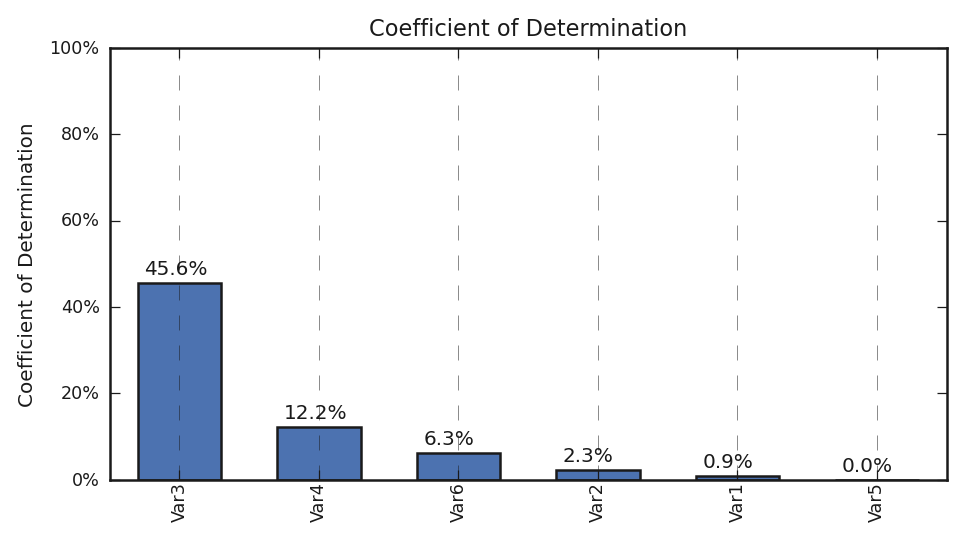

```python
ir=0
corr=df.corr()
corr=corr['Target'].drop(['Target'])
coefs=corr.values
coefs= np.array([i**2 for i in coefs])

# Plot the importance of features
font = {'size'   : 7}
plt.rc('font', **font)
fig, ax1 = plt.subplots(figsize=(6, 3), dpi= 180, facecolor='w', edgecolor='k')

_=prfrmnce_plot(coefs, title=f'Coefficient of Determination',
            ylabel='Coefficient of Determination',clmns=features_colums,titlefontsize=9,
            xfontsize=7, yfontsize=8).bargraph(perent=True,fontsizelable=8,xshift=-0.25,axt=ax1,
            yshift=0.02,ylim=[0,1], xlim=[-0.5,5.5], y_rot=0)
```

# Probability Distributions

- **Hacker statistics**
  - Use simulated repeated measurement to compute probabilities
  - Determine how to simulate data
  - Simulated many many times
  - Probability is approximately fraction of trials with the outcome of interest
- **Bernoulli trial**
  - An experiment that has two options, "success" (True) and failure (False)
- **Probability Mass Function (PMF)**
  - The set of probabilities of discrete outcomes
- **Probability Distribution**
  - A mathematical description of outcome
- **Binomial distribution**
  - The number r of success in n Bernoulli trials with probability p of success, is Binomially distributed. For example, the number of the heads in 4 coin flips with probability 0.5 of heads, is Binomially distributed.
- **Probability Density Function (PDF)**
  - Continuous Variables: Quantities that can take any value, not just discrete values
  - Continuous analog to PMF (probability mass function)
  - Mathematical description of the relative likelihood of observing a value of a continuous variable.
  - for PDF of normal distribution: the area under PDF is the probability of occurring a value.

## The Binomial PMF

In probability theory and statistics, the binomial distribution with parameters n and p is the discrete probability distribution of the number of successes in a sequence of n independent experiments, each asking a yes–no question.

The probability density for the binomial distribution is

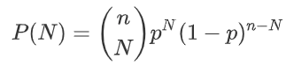

where *n* is the number of trials, *p* is the probability of success, and *N* is the number of successes.

[figure not shown]

```python
Samples=np.random.binomial(n=60,p=0.1,size=10000)
font = {'size'   : 11}
plt.rc('font', **font)
fig, ax1 = plt.subplots(figsize=(8, 8), dpi= 130, facecolor='w', edgecolor='k')
title='Binomial PMF, n=60, p=0.1, size=1000'

ax1=plt.subplot(2,1,1)
EDA_plot.histplt (Samples,bins=800,title=title,xlabl=None,
         ylabl='Percentage',xlimt=(0,15),ylimt=(0,0.2),axt=ax1,
         scale=1.15,loc=1,font=10,color='g')

ax1=plt.subplot(2,1,2)
EDA_plot.CDF_plot(Samples,1,label='Binomial ecdf',colors='g',xlabel=None,title=title,ylabel='Cumulative Probability',bins=10000,
    xlim=(0,15),ylim=(0,1),linewidth=2.5,loc=4,axt=ax1,x_ftze=12,y_ftze=12,tit_ftze=16,leg_ftze=9)
```

## Poisson processes and the Poisson Distribution

The timing of the next event is completely independent of when the previous even happened. The example are:

- Natural births in a given hospital
- Hit on a website during a given hour
- meteor strikes
- Molecular collisions in a gas
- Aviation incidents
- Buses in Poissonville
- The number of r of arrivals of a Poisson process in a given time interval with average rate of? arrivals per intervals is Poisson distributed.
- The number of r hits on a website in one hour with an average hit rate of 6 hits per hour is Poisson distributed

**Poisson distribution is the limit of the Binomial distribution for low probability of success and large number of Bernoulli trial** (`an experiment that has two options, "success" (True) and failure (False)`).

In probability theory and statistics, the Poisson distribution is a discrete probability distribution that expresses the probability of a given number of events occurring in a **fixed interval of time (or space)** if these events occur with a **known constant mean rate**:

$\LARGE P(n)=\frac{\mu ^{n}e^{-\mu}}{n!}$

where $P(n)$ is predicted probability for $n$ number of occurrence, $\mu$ is the mean for number occurrence for a fixed interval of time

- Small example

A small company, **on average**, is receiving *12* customers per day ($\mu=12$). What is the probability if the company will receive exactly *8* ($n=8$) customers in one day?

$\large P(n=8)=\frac{12 ^{8}e^{-12}}{8!}=0.0655$

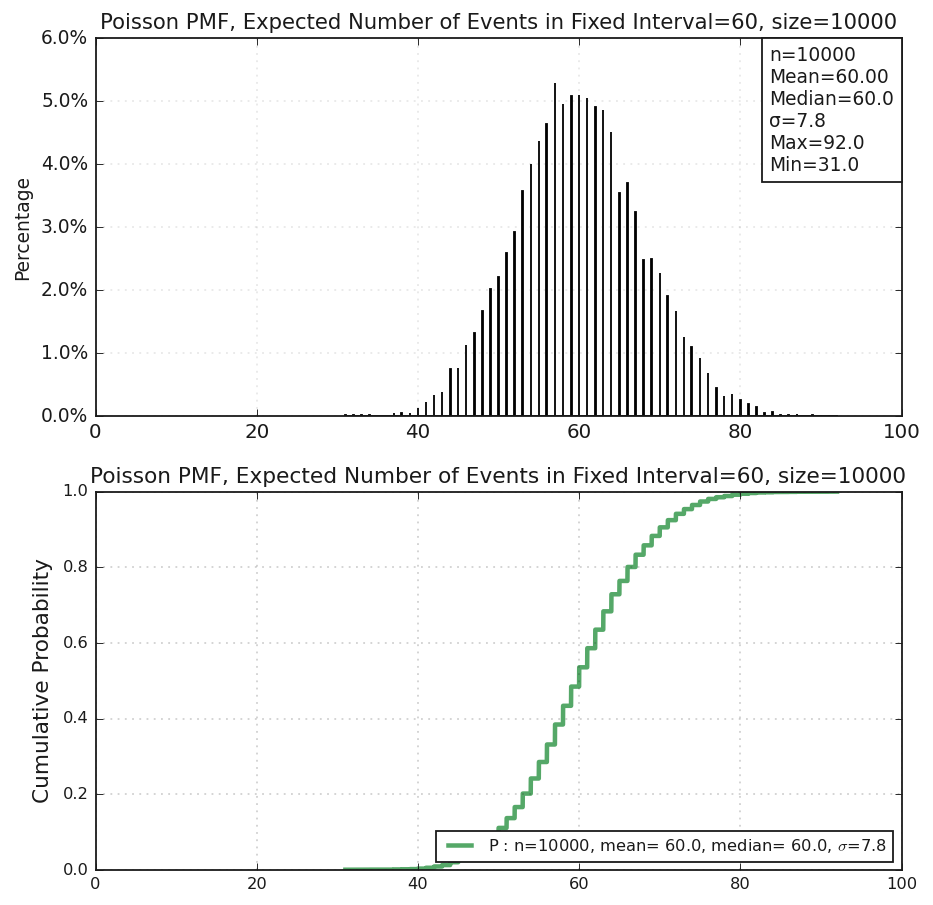

```python
# Draw samples from a Poisson distribution.
Samples=np.random.poisson(lam=60,size=10000)
# lam: Expected number of events occurring in a fixed-time interval,
font = {'size'   : 11}
plt.rc('font', **font)
fig, ax1 = plt.subplots(figsize=(8, 8), dpi= 130, facecolor='w', edgecolor='k')
title='Poisson PMF, Expected Number of Events in Fixed Interval=60, size=10000'

ax1=plt.subplot(2,1,1)
EDA_plot.histplt (Samples,bins=1000,title=title,xlabl=None,
         ylabl='Percentage',xlimt=(0,100),ylimt=None,axt=ax1,
         scale=1.15,loc=1,font=9,color='g')
#
ax1=plt.subplot(2,1,2)
EDA_plot.CDF_plot(Samples,1,label='Poisson ecdf',colors='g',xlabel=None,title=title,ylabel='Cumulative Probability',bins=10000,
    xlim=(0,100),ylim=None,linewidth=2.5,loc=4,axt=ax1,x_ftze=12,y_ftze=12,tit_ftze=12,leg_ftze=9)
```

## Normal Distribution

[figure not shown]

```python
# Draw samples from a Normal distribution.
Samples=np.random.normal(loc=3, scale=1.0, size=10000)

font = {'size'   : 11}
plt.rc('font', **font)
fig, ax1 = plt.subplots(figsize=(8, 8), dpi= 130, facecolor='w', edgecolor='k')
title='Normal Distribution_loc=3, scale=1.0, size=1000'

ax1=plt.subplot(2,1,1)
EDA_plot.histplt (Samples,bins=50,title=title,xlabl=None,
         ylabl='Percentage',xlimt=(0,6),ylimt=None,axt=ax1,
         scale=1.15,loc=1,font=10,color='g')


ax1=plt.subplot(2,1,2)
EDA_plot.CDF_plot(Samples,1,label='Normal ecdf',colors='g',xlabel=None,title='ecdf of '+title,ylabel='Cumulative Probability',bins=10000,
    xlim=(0,6),ylim=None,linewidth=2.5,loc=4,axt=ax1,x_ftze=12,y_ftze=12,tit_ftze=14,leg_ftze=9)
```

## The Exponential Distribution

The waiting time between arrivals of a Poisson process is Exponentially distributed.

[figure not shown]

```python
# Draw samples from a Exponential distribution.
Samples=np.random.exponential(scale=1.0,size=10000)
font = {'size'   : 11}
plt.rc('font', **font)
fig, ax1 = plt.subplots(figsize=(8, 8), dpi= 130, facecolor='w', edgecolor='k')
title='Exponential Distribution_scale=60, size=10000'

ax1=plt.subplot(2,1,1)
EDA_plot.histplt (Samples,bins=100,title=title,xlabl=None,
         ylabl='Percentage',xlimt=(0,10),ylimt=None,axt=ax1,
         scale=1.15,loc=1,font=10,color='g')


ax1=plt.subplot(2,1,2)
EDA_plot.CDF_plot(Samples,1,label='Poisson ecdf',colors='g',xlabel=None,title=title,ylabel='Cumulative Probability',bins=10000,
    xlim=(0,10),ylim=None,linewidth=2.5,loc=4,axt=ax1,x_ftze=12,y_ftze=12,tit_ftze=14,leg_ftze=9)
```

# Data Manipulation with Pandas

[Pandas](http://pandas.pydata.org/) is an open source Python package for data manipulation and analysis with high-performance and easy-to-use methods. It is based on the [dataframe](http://pandas.pydata.org/pandas-docs/stable/generated/pandas.DataFrame.html) concept in the [R programming language](https://www.r-project.org/about.html). Pandas can be used as the primary tools for data processing, data manipulation and data cleaning. pandas is built on NumPy and Matplotlib.

## Look at Data

```python
# Reading data in Pandas
import pandas as pd
df = pd.read_csv("./Data/WPD.csv") # Read data file
#df.head()
df[0:5] # Display data
```

|  | X Coordinate | Y Coordinate | Measured Depth (m) | Deviation (True/False) | Surface-Casing Weight (kg/m) | Production-Casing Size (mm) | Production-Casing Weight (kg/m) | Bore. Temp. (degC) | Prod. Formation | Porosity (fraction) | Permeability (Darcy) | OIL Prod. (e3m3/month) |
| --- | --- | --- | --- | --- | --- | --- | --- | --- | --- | --- | --- | --- |
| 0 | 352.6 | 372 | 2145.8 | False | NaN | 114.3 | NaN | 53.0 | Shale-Sand | 0.224 | 12.25 | 108.75 |
| 1 | 435.7 | 551 | 1638.0 | True | 25.3 | 114.3 | 17.3 | NaN | Sand | 0.118 | 4.11 | 0.33 |
| 2 | 37.7 | 788 | 3984.0 | True | 35.7 | 114.3 | 22.5 | NaN | Shale | 0.121 | 1.99 | 21.87 |
| 3 | 346.7 | 311 | 3809.0 | True | 41.7 | 114.3 | 17.3 | NaN | Sand | 0.170 | 5.84 | 46.30 |
| 4 | 254.6 | 727 | 2335.0 | True | 53.6 | NaN | NaN | 32.0 | Sand | 0.158 | 5.25 | 17.53 |

```python
# shape of data
df.shape
```

```
(1000, 12)
```

The **columns** function gives the name of the columns in your data file.

```python
column=list(df.columns)
print(column)
```

```
['X Coordinate', 'Y Coordinate', 'Measured Depth (m)', 'Deviation (True/False)', 'Surface-Casing Weight (kg/m)', 'Production-Casing Size (mm)', 'Production-Casing Weight (kg/m)', 'Bore. Temp. (degC)', 'Prod. Formation', 'Porosity (fraction)', 'Permeability (Darcy)', 'OIL Prod. (e3m3/month)']
```

The **info()** function gives some information about the data type: string float or null (missing values).

```python
df.info()
```

```
<class 'pandas.core.frame.DataFrame'>
RangeIndex: 1000 entries, 0 to 999
Data columns (total 12 columns):
 #   Column                           Non-Null Count  Dtype
---  ------                           --------------  -----
 0   X Coordinate                     1000 non-null   float64
 1   Y Coordinate                     1000 non-null   int64
 2   Measured Depth (m)               1000 non-null   float64
 3   Deviation (True/False)           1000 non-null   bool
 4   Surface-Casing Weight (kg/m)     593 non-null    float64
 5   Production-Casing Size (mm)      913 non-null    float64
 6   Production-Casing Weight (kg/m)  547 non-null    float64
 7   Bore. Temp. (degC)               801 non-null    float64
 8   Prod. Formation                  1000 non-null   object
 9   Porosity (fraction)              1000 non-null   float64
 10  Permeability (Darcy)             1000 non-null   float64
 11  OIL Prod. (e3m3/month)           1000 non-null   float64
dtypes: bool(1), float64(9), int64(1), object(1)
memory usage: 87.0+ KB
```

The **describe** function gives some statistical analysis for each column if the data type is not string.

```python
df.describe()
```

|  | X Coordinate | Y Coordinate | Measured Depth (m) | Surface-Casing Weight (kg/m) | Production-Casing Size (mm) | Production-Casing Weight (kg/m) | Bore. Temp. (degC) | Porosity (fraction) | Permeability (Darcy) | OIL Prod. (e3m3/month) |
| --- | --- | --- | --- | --- | --- | --- | --- | --- | --- | --- |
| count | 1000.000000 | 1000.000000 | 1000.000000 | 593.000000 | 913.000000 | 547.000000 | 801.000000 | 1000.000000 | 1000.000000 | 1000.000000 |
| mean | 432.893400 | 489.749000 | 1364.379300 | 42.906745 | 142.495290 | 23.260512 | 40.774032 | 0.141840 | 5.269140 | 60.003280 |
| std | 172.206682 | 243.547912 | 855.633567 | 25.877438 | 25.953205 | 7.137579 | 21.256825 | 0.074501 | 8.665687 | 234.814659 |
| min | 12.300000 | 36.000000 | 276.000000 | 14.100000 | 13.700000 | 10.800000 | 5.000000 | 0.000000 | 0.050000 | 0.000000 |
| 25% | 325.425000 | 339.750000 | 704.000000 | 35.700000 | 114.300000 | 17.300000 | 27.000000 | 0.089750 | 1.040000 | 0.000000 |
| 50% | 487.250000 | 480.000000 | 1066.000000 | 35.700000 | 139.700000 | 20.800000 | 33.000000 | 0.141000 | 2.480000 | 4.715000 |
| 75% | 581.675000 | 596.000000 | 1790.000000 | 48.100000 | 177.800000 | 25.300000 | 53.000000 | 0.192000 | 5.752500 | 33.117500 |
| max | 648.800000 | 1172.000000 | 6363.000000 | 595.000000 | 219.100000 | 53.600000 | 255.000000 | 0.400000 | 94.510000 | 3425.530000 |

```python
# Components of DataFrame
df.values
```

```
array([[352.6, 372, 2145.8, ..., 0.224, 12.25, 108.75],
       [435.7, 551, 1638.0, ..., 0.118, 4.11, 0.33],
       [37.7, 788, 3984.0, ..., 0.121, 1.99, 21.87],
       ...,
       [593.4, 456, 683.7, ..., 0.332, 49.75, 832.45],
       [540.9, 328, 1346.0, ..., 0.111, 0.59, 0.0],
       [617.8, 377, 844.0, ..., 0.292, 9.95, 153.43]], dtype=object)
```

```python
# index of DataFrame
df.index
```

```
RangeIndex(start=0, stop=1000, step=1)
```

## Data Cleaning

### Missing (NaN) Values

It is ideal to have valid value for every rows and columns. In reality, missing values is one of the main challenges faced by machine learning. There are some approaches in practice to deal with missing values.

**Option 1: Drop Column**

One naive approach is to remove columns that have missing values with **drop()** function.

```python
Select_column=column[3:8] # Select columns that have missing
Select_column
```

```
['Deviation (True/False)',
 'Surface-Casing Weight (kg/m)',
 'Production-Casing Size (mm)',
 'Production-Casing Weight (kg/m)',
 'Bore. Temp. (degC)']
```

```python
df_drop_c=df.copy() # Copy to avoid modifying the original data
df_drop_c.drop(Select_column,axis=1, inplace=True)  # Drop selected 5 columns
df_drop_c[:5]
```

|  | X Coordinate | Y Coordinate | Measured Depth (m) | Prod. Formation | Porosity (fraction) | Permeability (Darcy) | OIL Prod. (e3m3/month) |
| --- | --- | --- | --- | --- | --- | --- | --- |
| 0 | 352.6 | 372 | 2145.8 | Shale-Sand | 0.224 | 12.25 | 108.75 |
| 1 | 435.7 | 551 | 1638.0 | Sand | 0.118 | 4.11 | 0.33 |
| 2 | 37.7 | 788 | 3984.0 | Shale | 0.121 | 1.99 | 21.87 |
| 3 | 346.7 | 311 | 3809.0 | Sand | 0.170 | 5.84 | 46.30 |
| 4 | 254.6 | 727 | 2335.0 | Sand | 0.158 | 5.25 | 17.53 |

```python
df_drop_c.info()
```

```
<class 'pandas.core.frame.DataFrame'>
RangeIndex: 1000 entries, 0 to 999
Data columns (total 7 columns):
 #   Column                  Non-Null Count  Dtype
---  ------                  --------------  -----
 0   X Coordinate            1000 non-null   float64
 1   Y Coordinate            1000 non-null   int64
 2   Measured Depth (m)      1000 non-null   float64
 3   Prod. Formation         1000 non-null   object
 4   Porosity (fraction)     1000 non-null   float64
 5   Permeability (Darcy)    1000 non-null   float64
 6   OIL Prod. (e3m3/month)  1000 non-null   float64
dtypes: float64(5), int64(1), object(1)
memory usage: 54.8+ KB
```

**Option 2: Drop Row**

Another approach is to remove rows that have missing values with **dropna()** function.

```python
df_drop_=df.copy() # Copy to avoid modifying the original data
df_drop_r=df_drop_.dropna() # Drop rows with missing values
df_drop_r[:5]
```

|  | X Coordinate | Y Coordinate | Measured Depth (m) | Deviation (True/False) | Surface-Casing Weight (kg/m) | Production-Casing Size (mm) | Production-Casing Weight (kg/m) | Bore. Temp. (degC) | Prod. Formation | Porosity (fraction) | Permeability (Darcy) | OIL Prod. (e3m3/month) |
| --- | --- | --- | --- | --- | --- | --- | --- | --- | --- | --- | --- | --- |
| 6 | 636.9 | 462 | 713.0 | True | 48.1 | 177.8 | 25.3 | 27.0 | Shale | 0.128 | 0.70 | 0.0 |
| 7 | 556.2 | 441 | 761.0 | False | 35.7 | 139.7 | 20.8 | 28.0 | Sand | 0.055 | 0.36 | 0.0 |
| 8 | 572.0 | 521 | 587.0 | False | 25.3 | 114.3 | 14.1 | 15.0 | Shale | 0.033 | 0.46 | 0.0 |
| 10 | 366.2 | 385 | 1801.0 | False | 35.7 | 139.7 | 25.3 | 52.0 | Shale-Sand | 0.147 | 3.15 | 5.8 |
| 14 | 648.7 | 275 | 920.0 | False | 35.7 | 139.7 | 20.8 | 30.0 | Shale | 0.104 | 0.38 | 0.0 |

```python
df_drop_r.info()
```

```
<class 'pandas.core.frame.DataFrame'>
Int64Index: 426 entries, 6 to 999
Data columns (total 12 columns):
 #   Column                           Non-Null Count  Dtype
---  ------                           --------------  -----
 0   X Coordinate                     426 non-null    float64
 1   Y Coordinate                     426 non-null    int64
 2   Measured Depth (m)               426 non-null    float64
 3   Deviation (True/False)           426 non-null    bool
 4   Surface-Casing Weight (kg/m)     426 non-null    float64
 5   Production-Casing Size (mm)      426 non-null    float64
 6   Production-Casing Weight (kg/m)  426 non-null    float64
 7   Bore. Temp. (degC)               426 non-null    float64
 8   Prod. Formation                  426 non-null    object
 9   Porosity (fraction)              426 non-null    float64
 10  Permeability (Darcy)             426 non-null    float64
 11  OIL Prod. (e3m3/month)           426 non-null    float64
dtypes: bool(1), float64(9), int64(1), object(1)
memory usage: 40.4+ KB
```

This approach is also not recommend because number of data (rows) have decreased from 1000 to 426.

**Option 3: Replace with Median (mean)**

A common practice is to replace missing values with the median (mean) value for that column. The median is the middle value of a list that 50% are less and 50% are bigger. See [Median](https://www.mathsisfun.com/median.html). The following code replaces all missing values in 5 columns with the median value of each column values.

```python
df_im=df.copy()

# Get the median of each variable and replace the missing values with median
for i in range(len(Select_column)):
    P50 = df[Select_column[i]].median() # Calculate median of each column
    df_im[Select_column[i]] = df_im[Select_column[i]].fillna(P50)   # replace NaN with median(P50)

df_im[:5]
```

|  | X Coordinate | Y Coordinate | Measured Depth (m) | Deviation (True/False) | Surface-Casing Weight (kg/m) | Production-Casing Size (mm) | Production-Casing Weight (kg/m) | Bore. Temp. (degC) | Prod. Formation | Porosity (fraction) | Permeability (Darcy) | OIL Prod. (e3m3/month) |
| --- | --- | --- | --- | --- | --- | --- | --- | --- | --- | --- | --- | --- |
| 0 | 352.6 | 372 | 2145.8 | False | 35.7 | 114.3 | 20.8 | 53.0 | Shale-Sand | 0.224 | 12.25 | 108.75 |
| 1 | 435.7 | 551 | 1638.0 | True | 25.3 | 114.3 | 17.3 | 33.0 | Sand | 0.118 | 4.11 | 0.33 |
| 2 | 37.7 | 788 | 3984.0 | True | 35.7 | 114.3 | 22.5 | 33.0 | Shale | 0.121 | 1.99 | 21.87 |
| 3 | 346.7 | 311 | 3809.0 | True | 41.7 | 114.3 | 17.3 | 33.0 | Sand | 0.170 | 5.84 | 46.30 |
| 4 | 254.6 | 727 | 2335.0 | True | 53.6 | 139.7 | 20.8 | 32.0 | Sand | 0.158 | 5.25 | 17.53 |

```python
df_im.info()
```

```
<class 'pandas.core.frame.DataFrame'>
RangeIndex: 1000 entries, 0 to 999
Data columns (total 12 columns):
 #   Column                           Non-Null Count  Dtype
---  ------                           --------------  -----
 0   X Coordinate                     1000 non-null   float64
 1   Y Coordinate                     1000 non-null   int64
 2   Measured Depth (m)               1000 non-null   float64
 3   Deviation (True/False)           1000 non-null   bool
 4   Surface-Casing Weight (kg/m)     1000 non-null   float64
 5   Production-Casing Size (mm)      1000 non-null   float64
 6   Production-Casing Weight (kg/m)  1000 non-null   float64
 7   Bore. Temp. (degC)               1000 non-null   float64
 8   Prod. Formation                  1000 non-null   object
 9   Porosity (fraction)              1000 non-null   float64
 10  Permeability (Darcy)             1000 non-null   float64
 11  OIL Prod. (e3m3/month)           1000 non-null   float64
dtypes: bool(1), float64(9), int64(1), object(1)
memory usage: 87.0+ KB
```

- **Dropping duplicate names**

  `df.drop_duplicates(subset="name")`

  `df.drop_duplicates(subset=["name1","name2"])`

### Remove Outliers

Outliers are usually extreme high or low values that are different from pattern of majority data. Outliers should be removed from dataset (we should be careful not to consider novelty as outlier). A straightforward approach to detect outliers are several (n) [standard deviations](https://www.mathsisfun.com/data/standard-deviation.html) from the mean $m\pm n\sigma$ ($m$=mean, $\sigma$=standard deviation). For example, an outlier can bigger than $m+ 3\sigma $ or less than can bigger than $m- 3\sigma $. The following function can be used to apply this approach.

```python
def outlier_remove(df, n,name):
    """Delete rows for a specified column where values are out of +/- n*sd standard deviations

    df  : Pandas dataframe
    n   : n in the equation 𝑚±𝑛𝜎
    name: Column name
    """
    mean=df[name].mean() # Calclute mean of column
    sd=df[name].std()  # Calclute standard deviation of column
    drop_r = df.index[(mean -n * sd> df[name]) | (mean+n * sd< df[name])] # Find data that are not within 𝑚±𝑛𝜎
    df.drop(drop_r, axis=0, inplace=True) # Drop data
    df.reset_index(inplace=True, drop=True) # Reset index
```

```python
# Drop outliers in last column 'OIL Prod. (e3m3/month)'
df_im_out=df_im.copy()
outlier_remove(df_im_out,n=3,name='OIL Prod. (e3m3/month)')
df_im_out[:5]
```

|  | X Coordinate | Y Coordinate | Measured Depth (m) | Deviation (True/False) | Surface-Casing Weight (kg/m) | Production-Casing Size (mm) | Production-Casing Weight (kg/m) | Bore. Temp. (degC) | Prod. Formation | Porosity (fraction) | Permeability (Darcy) | OIL Prod. (e3m3/month) |
| --- | --- | --- | --- | --- | --- | --- | --- | --- | --- | --- | --- | --- |
| 0 | 352.6 | 372 | 2145.8 | False | 35.7 | 114.3 | 20.8 | 53.0 | Shale-Sand | 0.224 | 12.25 | 108.75 |
| 1 | 435.7 | 551 | 1638.0 | True | 25.3 | 114.3 | 17.3 | 33.0 | Sand | 0.118 | 4.11 | 0.33 |
| 2 | 37.7 | 788 | 3984.0 | True | 35.7 | 114.3 | 22.5 | 33.0 | Shale | 0.121 | 1.99 | 21.87 |
| 3 | 346.7 | 311 | 3809.0 | True | 41.7 | 114.3 | 17.3 | 33.0 | Sand | 0.170 | 5.84 | 46.30 |
| 4 | 254.6 | 727 | 2335.0 | True | 53.6 | 139.7 | 20.8 | 32.0 | Sand | 0.158 | 5.25 | 17.53 |

### Concatenation

A new data frames can be built by concatenating rows and columns. A new dataframe is created by concatenating two columns together 'Measured Depth (m)' and 'OIL Prod. (e3m3/month)' using the **concat()** function.

```python
col_1= df_im['Measured Depth (m)']
col_2 = df_im['OIL Prod. (e3m3/month)']
result = pd.concat([col_1, col_2], axis=1)
result[:5]
```

|  | Measured Depth (m) | OIL Prod. (e3m3/month) |
| --- | --- | --- |
| 0 | 2145.8 | 108.75 |
| 1 | 1638.0 | 0.33 |
| 2 | 3984.0 | 21.87 |
| 3 | 3809.0 | 46.30 |
| 4 | 2335.0 | 17.53 |

Two rows can be concatenated together using **concat()** function. The code below concatenates the first 4 rows and the last 3 rows of the previous dataset after imputation.

```python
row_1= df_im[0:4]  # Retrieve first 4 rows
row_2 = df_im[-4:-1]  # Retrieve last 3 rows
result = pd.concat([row_1, row_2], axis=0) # Concatenate rows
result[:5]
```

|  | X Coordinate | Y Coordinate | Measured Depth (m) | Deviation (True/False) | Surface-Casing Weight (kg/m) | Production-Casing Size (mm) | Production-Casing Weight (kg/m) | Bore. Temp. (degC) | Prod. Formation | Porosity (fraction) | Permeability (Darcy) | OIL Prod. (e3m3/month) |
| --- | --- | --- | --- | --- | --- | --- | --- | --- | --- | --- | --- | --- |
| 0 | 352.6 | 372 | 2145.8 | False | 35.7 | 114.3 | 20.8 | 53.0 | Shale-Sand | 0.224 | 12.25 | 108.75 |
| 1 | 435.7 | 551 | 1638.0 | True | 25.3 | 114.3 | 17.3 | 33.0 | Sand | 0.118 | 4.11 | 0.33 |
| 2 | 37.7 | 788 | 3984.0 | True | 35.7 | 114.3 | 22.5 | 33.0 | Shale | 0.121 | 1.99 | 21.87 |
| 3 | 346.7 | 311 | 3809.0 | True | 41.7 | 114.3 | 17.3 | 33.0 | Sand | 0.170 | 5.84 | 46.30 |
| 996 | 548.3 | 475 | 749.8 | False | 35.7 | 114.3 | 20.8 | 28.0 | Shale | 0.017 | 0.48 | 0.00 |

### Saving a Dataframe as CSV

```python
filename="myfile.csv"
df_im.to_csv(filename, index=False) # index = False not writing row numbers
```

### Shuffling, Grouping and Sorting

**Shuffling Dataset**

An example of shuffling is playing the game of cards. All the cards are collected at the end of each round of play, shuffled to ensure that cards are distributed randomly and each player receives cards based on chance. In Machine Learning, the data set should be split into training and validation datasets. So, shuffling is very important to avoid any element of bias/patterns in the split datasets.

If consistent shuffling of the data set is required for several times of running the code, a random seed can be used. See code below.

```python
import numpy as np

#np.random.seed(82)
df_shfl = df_im.reindex(np.random.permutation(df.index))
df_shfl.reset_index(inplace=True, drop=True) # Reset index
df_shfl[0:5]
```

|  | X Coordinate | Y Coordinate | Measured Depth (m) | Deviation (True/False) | Surface-Casing Weight (kg/m) | Production-Casing Size (mm) | Production-Casing Weight (kg/m) | Bore. Temp. (degC) | Prod. Formation | Porosity (fraction) | Permeability (Darcy) | OIL Prod. (e3m3/month) |
| --- | --- | --- | --- | --- | --- | --- | --- | --- | --- | --- | --- | --- |
| 0 | 498.9 | 59 | 1010.0 | False | 53.6 | 139.7 | 20.8 | 26.0 | Shale-Sand | 0.100 | 0.66 | 0.00 |
| 1 | 320.3 | 468 | 1436.8 | False | 35.7 | 139.7 | 20.8 | 41.0 | Sand | 0.134 | 3.50 | 2.02 |
| 2 | 298.7 | 674 | 3065.0 | True | 53.6 | 139.7 | 20.8 | 33.0 | Sand | 0.338 | 42.45 | 1760.45 |
| 3 | 569.8 | 205 | 989.1 | False | 35.7 | 114.3 | 20.8 | 33.0 | Shale | 0.018 | 0.91 | 0.00 |
| 4 | 522.3 | 213 | 1050.0 | False | 35.7 | 139.7 | 23.1 | 35.0 | Shale | 0.157 | 9.48 | 37.06 |

**Sorting Data Set**

```python
df_sort = df_im.sort_values(by='Measured Depth (m)', ascending=True)
#df_sort.reset_index(inplace=True, drop=True) # Reset index
df_sort[:5]
```

|  | X Coordinate | Y Coordinate | Measured Depth (m) | Deviation (True/False) | Surface-Casing Weight (kg/m) | Production-Casing Size (mm) | Production-Casing Weight (kg/m) | Bore. Temp. (degC) | Prod. Formation | Porosity (fraction) | Permeability (Darcy) | OIL Prod. (e3m3/month) |
| --- | --- | --- | --- | --- | --- | --- | --- | --- | --- | --- | --- | --- |
| 90 | 132.0 | 1104 | 276.0 | False | 25.3 | 114.3 | 14.1 | 25.0 | Shale | 0.142 | 1.16 | 0.00 |
| 537 | 72.9 | 784 | 295.5 | False | 25.3 | 114.3 | 14.1 | 22.0 | Shale | 0.000 | 0.66 | 0.00 |
| 403 | 591.3 | 791 | 297.0 | False | 25.3 | 114.3 | 14.1 | 26.0 | Shale | 0.142 | 13.37 | 72.26 |
| 507 | 621.7 | 593 | 321.0 | True | 53.6 | 177.8 | 34.2 | 33.0 | Shale | 0.091 | 1.72 | 0.00 |
| 105 | 631.2 | 583 | 343.2 | False | 56.5 | 139.7 | 20.8 | 33.0 | Sand | 0.168 | 3.19 | 19.23 |

we can sort values with multiple variables:

```python
df_sort = df_im.sort_values(['Measured Depth (m)','Porosity (fraction)'], ascending=[True, False])
df_sort[:5]
```

|  | X Coordinate | Y Coordinate | Measured Depth (m) | Deviation (True/False) | Surface-Casing Weight (kg/m) | Production-Casing Size (mm) | Production-Casing Weight (kg/m) | Bore. Temp. (degC) | Prod. Formation | Porosity (fraction) | Permeability (Darcy) | OIL Prod. (e3m3/month) |
| --- | --- | --- | --- | --- | --- | --- | --- | --- | --- | --- | --- | --- |
| 90 | 132.0 | 1104 | 276.0 | False | 25.3 | 114.3 | 14.1 | 25.0 | Shale | 0.142 | 1.16 | 0.00 |
| 537 | 72.9 | 784 | 295.5 | False | 25.3 | 114.3 | 14.1 | 22.0 | Shale | 0.000 | 0.66 | 0.00 |
| 403 | 591.3 | 791 | 297.0 | False | 25.3 | 114.3 | 14.1 | 26.0 | Shale | 0.142 | 13.37 | 72.26 |
| 507 | 621.7 | 593 | 321.0 | True | 53.6 | 177.8 | 34.2 | 33.0 | Shale | 0.091 | 1.72 | 0.00 |
| 105 | 631.2 | 583 | 343.2 | False | 56.5 | 139.7 | 20.8 | 33.0 | Sand | 0.168 | 3.19 | 19.23 |

Subsetting based on multiple conditions:

```python
is_lab   = df["Measured Depth (m)"]     == 321.0
is_brown = df["Deviation (True/False)"] == True
df[is_lab & is_brown]
```

|  | X Coordinate | Y Coordinate | Measured Depth (m) | Deviation (True/False) | Surface-Casing Weight (kg/m) | Production-Casing Size (mm) | Production-Casing Weight (kg/m) | Bore. Temp. (degC) | Prod. Formation | Porosity (fraction) | Permeability (Darcy) | OIL Prod. (e3m3/month) |
| --- | --- | --- | --- | --- | --- | --- | --- | --- | --- | --- | --- | --- |
| 507 | 621.7 | 593 | 321.0 | True | 53.6 | 177.8 | 34.2 | NaN | Shale | 0.091 | 1.72 | 0.0 |

Subsetting using .isin()

```python
df_sort[df_sort['Prod. Formation'].isin(['Sand'])][:5]
```

|  | X Coordinate | Y Coordinate | Measured Depth (m) | Deviation (True/False) | Surface-Casing Weight (kg/m) | Production-Casing Size (mm) | Production-Casing Weight (kg/m) | Bore. Temp. (degC) | Prod. Formation | Porosity (fraction) | Permeability (Darcy) | OIL Prod. (e3m3/month) |
| --- | --- | --- | --- | --- | --- | --- | --- | --- | --- | --- | --- | --- |
| 105 | 631.2 | 583 | 343.2 | False | 56.5 | 139.7 | 20.8 | 33.0 | Sand | 0.168 | 3.19 | 19.23 |
| 918 | 607.5 | 592 | 409.0 | True | 48.1 | 177.8 | 29.7 | 21.0 | Sand | 0.050 | 0.66 | 0.00 |
| 92 | 589.3 | 596 | 436.0 | False | 48.1 | 177.8 | 25.3 | 18.0 | Sand | 0.166 | 11.82 | 17.42 |
| 793 | 571.8 | 598 | 445.0 | False | 53.6 | 177.8 | 34.2 | 18.0 | Sand | 0.084 | 1.01 | 0.00 |
| 560 | 621.3 | 595 | 455.0 | True | 48.1 | 177.8 | 29.8 | 27.0 | Sand | 0.262 | 8.87 | 121.89 |

## Summary statistics

Grouping is applied to summarize data. The attributes below are used to calculate summary statistics for each col or each row. The attributes by default calculate statistics for columns:

- `mean()`
- `median()`
- `mode()`
- `min()`
- `max()`
- `var()`
- `std()`
- `sum()`
- `quantile()`

The following codes performs grouping; generating summary statistics for each category for feature 'Prod. Formation' in target variable 'OIL Prod. (e3m3/month)'.

```python
gb_mean=df_im.groupby('Prod. Formation')['OIL Prod. (e3m3/month)'].mean()
gb_mean
```

```
Prod. Formation
Sand          64.015467
Shale         59.502943
Shale-Sand    54.482824
Name: OIL Prod. (e3m3/month), dtype: float64
```

```python
gb_sum=df_im.groupby('Prod. Formation')['OIL Prod. (e3m3/month)'].sum()
gb_sum
```

```
Prod. Formation
Sand          19204.64
Shale         31536.56
Shale-Sand     9262.08
Name: OIL Prod. (e3m3/month), dtype: float64
```

### `.agg()` Method

The `.agg()` method is used for computing costume summary statistics (`df['column'].agg(function)`)

```python
def pct90(clm):
    return clm.quantile(0.9)

df_im['OIL Prod. (e3m3/month)'].agg(pct90)
```

```
105.87400000000005
```

```python
df_im[['OIL Prod. (e3m3/month)','Measured Depth (m)']].agg(pct90)
```

```
OIL Prod. (e3m3/month)     105.874
Measured Depth (m)        2396.400
dtype: float64
```

```python
def pct30(clm):
    return clm.quantile(0.3)

df_im['OIL Prod. (e3m3/month)'].agg([pct30,pct90])
```

```
pct30      0.000
pct90    105.874
Name: OIL Prod. (e3m3/month), dtype: float64
```

### Cumulative sum

```python
df_im['OIL Prod. (e3m3/month)'].iloc[:5]
```

```
0    108.75
1      0.33
2     21.87
3     46.30
4     17.53
Name: OIL Prod. (e3m3/month), dtype: float64
```

```python
df_im['OIL Prod. (e3m3/month)'].iloc[:5].cumsum()
```

```
0    108.75
1    109.08
2    130.95
3    177.25
4    194.78
Name: OIL Prod. (e3m3/month), dtype: float64
```

There are other cumulative statistics:

- `cummax()`
- `cummin()`
- `cumprod()`

```python
df_im['OIL Prod. (e3m3/month)'].iloc[:5].cummax()
```

```
0    108.75
1    108.75
2    108.75
3    108.75
4    108.75
Name: OIL Prod. (e3m3/month), dtype: float64
```

```python
df_im['OIL Prod. (e3m3/month)'].iloc[:5].cummin()
```

```
0    108.75
1      0.33
2      0.33
3      0.33
4      0.33
Name: OIL Prod. (e3m3/month), dtype: float64
```

```python
df_im['OIL Prod. (e3m3/month)'].value_counts()
```

```
0.00      379
0.01       14
0.05       12
0.02        8
22.01       5
         ...
37.68       1
17.15       1
553.28      1
27.46       1
153.43      1
Name: OIL Prod. (e3m3/month), Length: 521, dtype: int64
```

### `groupby`

```python
df_im.groupby('Deviation (True/False)')['Measured Depth (m)'].agg([min,max,np.median])
```

| Deviation (True/False) | min | max | median |
| --- | --- | --- | --- |
| False | 276.0 | 3458.3 | 1025.0 |
| True | 321.0 | 6363.0 | 1354.5 |

```python
df_im.groupby('Deviation (True/False)')['Measured Depth (m)'].mean()
```

```
Deviation (True/False)
False    1214.885276
True     1644.465805
Name: Measured Depth (m), dtype: float64
```

### Pivot tables

```python
df_im.groupby('Deviation (True/False)')['Measured Depth (m)'].mean()
```

```
Deviation (True/False)
False    1214.885276
True     1644.465805
Name: Measured Depth (m), dtype: float64
```

```python
df_im.pivot_table(aggfunc='mean', values='Measured Depth (m)', index='Deviation (True/False)')
```

| Deviation (True/False) | Measured Depth (m) |
| --- | --- |
| False | 1214.885276 |
| True | 1644.465805 |

`values` argument is the column you want to summarize and `index` is the column you want to groupby.

```python
df_im.pivot_table(aggfunc=[np.median,np.std], values='Measured Depth (m)', index='Deviation (True/False)')
```

| Deviation (True/False) | median Measured Depth (m) | std Measured Depth (m) |
| --- | --- | --- |
| False | 1025.0 | 612.634963 |
| True | 1354.5 | 1132.657827 |

### Index

```python
df_im.columns
```

```
Index(['X Coordinate', 'Y Coordinate', 'Measured Depth (m)',
       'Deviation (True/False)', 'Surface-Casing Weight (kg/m)',
       'Production-Casing Size (mm)', 'Production-Casing Weight (kg/m)',
       'Bore. Temp. (degC)', 'Prod. Formation', 'Porosity (fraction)',
       'Permeability (Darcy)', 'OIL Prod. (e3m3/month)'],
      dtype='object')
```

```python
df_im.index
```

```
RangeIndex(start=0, stop=1000, step=1)
```

we can move a column from body of dataframe to index:

```python
df_im[:5].set_index("X Coordinate")
```

| X Coordinate | Y Coordinate | Measured Depth (m) | Deviation (True/False) | Surface-Casing Weight (kg/m) | Production-Casing Size (mm) | Production-Casing Weight (kg/m) | Bore. Temp. (degC) | Prod. Formation | Porosity (fraction) | Permeability (Darcy) | OIL Prod. (e3m3/month) |
| --- | --- | --- | --- | --- | --- | --- | --- | --- | --- | --- | --- |
| 352.6 | 372 | 2145.8 | False | 35.7 | 114.3 | 20.8 | 53.0 | Shale-Sand | 0.224 | 12.25 | 108.75 |
| 435.7 | 551 | 1638.0 | True | 25.3 | 114.3 | 17.3 | 33.0 | Sand | 0.118 | 4.11 | 0.33 |
| 37.7 | 788 | 3984.0 | True | 35.7 | 114.3 | 22.5 | 33.0 | Shale | 0.121 | 1.99 | 21.87 |
| 346.7 | 311 | 3809.0 | True | 41.7 | 114.3 | 17.3 | 33.0 | Sand | 0.170 | 5.84 | 46.30 |
| 254.6 | 727 | 2335.0 | True | 53.6 | 139.7 | 20.8 | 32.0 | Sand | 0.158 | 5.25 | 17.53 |

To undo what we just did we can reset_ndex():

```python
df_im[:5].reset_index(drop=True)
```

|  | X Coordinate | Y Coordinate | Measured Depth (m) | Deviation (True/False) | Surface-Casing Weight (kg/m) | Production-Casing Size (mm) | Production-Casing Weight (kg/m) | Bore. Temp. (degC) | Prod. Formation | Porosity (fraction) | Permeability (Darcy) | OIL Prod. (e3m3/month) |
| --- | --- | --- | --- | --- | --- | --- | --- | --- | --- | --- | --- | --- |
| 0 | 352.6 | 372 | 2145.8 | False | 35.7 | 114.3 | 20.8 | 53.0 | Shale-Sand | 0.224 | 12.25 | 108.75 |
| 1 | 435.7 | 551 | 1638.0 | True | 25.3 | 114.3 | 17.3 | 33.0 | Sand | 0.118 | 4.11 | 0.33 |
| 2 | 37.7 | 788 | 3984.0 | True | 35.7 | 114.3 | 22.5 | 33.0 | Shale | 0.121 | 1.99 | 21.87 |
| 3 | 346.7 | 311 | 3809.0 | True | 41.7 | 114.3 | 17.3 | 33.0 | Sand | 0.170 | 5.84 | 46.30 |
| 4 | 254.6 | 727 | 2335.0 | True | 53.6 | 139.7 | 20.8 | 32.0 | Sand | 0.158 | 5.25 | 17.53 |

Indexing makes subsetting simpler:

```python
df_im[df_im['Prod. Formation'].isin(['Shale', 'Sand'])][:5]
```

|  | X Coordinate | Y Coordinate | Measured Depth (m) | Deviation (True/False) | Surface-Casing Weight (kg/m) | Production-Casing Size (mm) | Production-Casing Weight (kg/m) | Bore. Temp. (degC) | Prod. Formation | Porosity (fraction) | Permeability (Darcy) | OIL Prod. (e3m3/month) |
| --- | --- | --- | --- | --- | --- | --- | --- | --- | --- | --- | --- | --- |
| 1 | 435.7 | 551 | 1638.0 | True | 25.3 | 114.3 | 17.3 | 33.0 | Sand | 0.118 | 4.11 | 0.33 |
| 2 | 37.7 | 788 | 3984.0 | True | 35.7 | 114.3 | 22.5 | 33.0 | Shale | 0.121 | 1.99 | 21.87 |
| 3 | 346.7 | 311 | 3809.0 | True | 41.7 | 114.3 | 17.3 | 33.0 | Sand | 0.170 | 5.84 | 46.30 |
| 4 | 254.6 | 727 | 2335.0 | True | 53.6 | 139.7 | 20.8 | 32.0 | Sand | 0.158 | 5.25 | 17.53 |
| 5 | 127.5 | 1125 | 1560.6 | False | 35.7 | 177.8 | 20.8 | 63.0 | Shale | 0.000 | 0.10 | 0.00 |

This is a long code, we can use subsetting as below:

```python
#df_im.set_index("Prod. Formation",inplace=True)
df_im[:5]
```

|  | X Coordinate | Y Coordinate | Measured Depth (m) | Deviation (True/False) | Surface-Casing Weight (kg/m) | Production-Casing Size (mm) | Production-Casing Weight (kg/m) | Bore. Temp. (degC) | Prod. Formation | Porosity (fraction) | Permeability (Darcy) | OIL Prod. (e3m3/month) |
| --- | --- | --- | --- | --- | --- | --- | --- | --- | --- | --- | --- | --- |
| 0 | 352.6 | 372 | 2145.8 | False | 35.7 | 114.3 | 20.8 | 53.0 | Shale-Sand | 0.224 | 12.25 | 108.75 |
| 1 | 435.7 | 551 | 1638.0 | True | 25.3 | 114.3 | 17.3 | 33.0 | Sand | 0.118 | 4.11 | 0.33 |
| 2 | 37.7 | 788 | 3984.0 | True | 35.7 | 114.3 | 22.5 | 33.0 | Shale | 0.121 | 1.99 | 21.87 |
| 3 | 346.7 | 311 | 3809.0 | True | 41.7 | 114.3 | 17.3 | 33.0 | Sand | 0.170 | 5.84 | 46.30 |
| 4 | 254.6 | 727 | 2335.0 | True | 53.6 | 139.7 | 20.8 | 32.0 | Sand | 0.158 | 5.25 | 17.53 |

```python
df.loc[0: 3]
```

|  | X Coordinate | Y Coordinate | Measured Depth (m) | Deviation (True/False) | Surface-Casing Weight (kg/m) | Production-Casing Size (mm) | Production-Casing Weight (kg/m) | Bore. Temp. (degC) | Prod. Formation | Porosity (fraction) | Permeability (Darcy) | OIL Prod. (e3m3/month) |
| --- | --- | --- | --- | --- | --- | --- | --- | --- | --- | --- | --- | --- |
| 0 | 352.6 | 372 | 2145.8 | False | NaN | 114.3 | NaN | 53.0 | Shale-Sand | 0.224 | 12.25 | 108.75 |
| 1 | 435.7 | 551 | 1638.0 | True | 25.3 | 114.3 | 17.3 | NaN | Sand | 0.118 | 4.11 | 0.33 |
| 2 | 37.7 | 788 | 3984.0 | True | 35.7 | 114.3 | 22.5 | NaN | Shale | 0.121 | 1.99 | 21.87 |
| 3 | 346.7 | 311 | 3809.0 | True | 41.7 | 114.3 | 17.3 | NaN | Sand | 0.170 | 5.84 | 46.30 |

**Multi-level indexes**

```python
df_im.set_index(["Porosity (fraction)","Permeability (Darcy)"],inplace=True)
```

```python
df_im[:5]
```

| Porosity (fraction) | Permeability (Darcy) | X Coordinate | Y Coordinate | Measured Depth (m) | Deviation (True/False) | Surface-Casing Weight (kg/m) | Production-Casing Size (mm) | Production-Casing Weight (kg/m) | Bore. Temp. (degC) | Prod. Formation | OIL Prod. (e3m3/month) |
| --- | --- | --- | --- | --- | --- | --- | --- | --- | --- | --- | --- |
| 0.224 | 12.25 | 352.6 | 372 | 2145.8 | False | 35.7 | 114.3 | 20.8 | 53.0 | Shale-Sand | 108.75 |
| 0.118 | 4.11 | 435.7 | 551 | 1638.0 | True | 25.3 | 114.3 | 17.3 | 33.0 | Sand | 0.33 |
| 0.121 | 1.99 | 37.7 | 788 | 3984.0 | True | 35.7 | 114.3 | 22.5 | 33.0 | Shale | 21.87 |
| 0.170 | 5.84 | 346.7 | 311 | 3809.0 | True | 41.7 | 114.3 | 17.3 | 33.0 | Sand | 46.30 |
| 0.158 | 5.25 | 254.6 | 727 | 2335.0 | True | 53.6 | 139.7 | 20.8 | 32.0 | Sand | 17.53 |

```python
df_im.loc[[(0.224,12.25), (0.017,0.48)]]
```

| Porosity (fraction) | Permeability (Darcy) | X Coordinate | Y Coordinate | Measured Depth (m) | Deviation (True/False) | Surface-Casing Weight (kg/m) | Production-Casing Size (mm) | Production-Casing Weight (kg/m) | Bore. Temp. (degC) | Prod. Formation | OIL Prod. (e3m3/month) |
| --- | --- | --- | --- | --- | --- | --- | --- | --- | --- | --- | --- |
| 0.224 | 12.25 | 352.6 | 372 | 2145.8 | False | 35.7 | 114.3 | 20.8 | 53.0 | Shale-Sand | 108.75 |
| 0.017 | 0.48 | 548.3 | 475 | 749.8 | False | 35.7 | 114.3 | 20.8 | 28.0 | Shale | 0.00 |

**Sorting by index values**

```python
df_im.sort_index()[:5]
```

| Porosity (fraction) | Permeability (Darcy) | X Coordinate | Y Coordinate | Measured Depth (m) | Deviation (True/False) | Surface-Casing Weight (kg/m) | Production-Casing Size (mm) | Production-Casing Weight (kg/m) | Bore. Temp. (degC) | Prod. Formation | OIL Prod. (e3m3/month) |
| --- | --- | --- | --- | --- | --- | --- | --- | --- | --- | --- | --- |
| 0.0 | 0.05 | 596.4 | 126 | 368.8 | False | 35.7 | 177.8 | 20.8 | 33.0 | Shale | 0.0 |
|  | 0.07 | 598.2 | 513 | 621.0 | True | 48.1 | 177.8 | 29.8 | 25.0 | Sand | 0.0 |
|  | 0.07 | 372.6 | 382 | 1914.0 | False | 35.7 | 139.7 | 23.1 | 46.0 | Shale | 0.0 |
|  | 0.10 | 127.5 | 1125 | 1560.6 | False | 35.7 | 177.8 | 20.8 | 63.0 | Shale | 0.0 |
|  | 0.10 | 427.0 | 555 | 1495.0 | True | 25.3 | 114.3 | 17.3 | 33.0 | Shale-Sand | 0.0 |

```python
df_im.sort_index(level=['Porosity (fraction)','Permeability (Darcy)'], ascending=[True, True])[:5]
```

| Porosity (fraction) | Permeability (Darcy) | X Coordinate | Y Coordinate | Measured Depth (m) | Deviation (True/False) | Surface-Casing Weight (kg/m) | Production-Casing Size (mm) | Production-Casing Weight (kg/m) | Bore. Temp. (degC) | Prod. Formation | OIL Prod. (e3m3/month) |
| --- | --- | --- | --- | --- | --- | --- | --- | --- | --- | --- | --- |
| 0.0 | 0.05 | 596.4 | 126 | 368.8 | False | 35.7 | 177.8 | 20.8 | 33.0 | Shale | 0.0 |
|  | 0.07 | 598.2 | 513 | 621.0 | True | 48.1 | 177.8 | 29.8 | 25.0 | Sand | 0.0 |
|  | 0.07 | 372.6 | 382 | 1914.0 | False | 35.7 | 139.7 | 23.1 | 46.0 | Shale | 0.0 |
|  | 0.10 | 127.5 | 1125 | 1560.6 | False | 35.7 | 177.8 | 20.8 | 63.0 | Shale | 0.0 |
|  | 0.10 | 427.0 | 555 | 1495.0 | True | 25.3 | 114.3 | 17.3 | 33.0 | Shale-Sand | 0.0 |

### Slicing by `.loc` and `.iloc`

`loc` does not get inner level index only it return outer level.

We can have two arguments for `loc` to include columns (`:` means return everything).

```python
df_im.loc[:,"X Coordinate":"Deviation (True/False)"][:5]
```

| Porosity (fraction) | Permeability (Darcy) | X Coordinate | Y Coordinate | Measured Depth (m) | Deviation (True/False) |
| --- | --- | --- | --- | --- | --- |
| 0.224 | 12.25 | 352.6 | 372 | 2145.8 | False |
| 0.118 | 4.11 | 435.7 | 551 | 1638.0 | True |
| 0.121 | 1.99 | 37.7 | 788 | 3984.0 | True |
| 0.170 | 5.84 | 346.7 | 311 | 3809.0 | True |
| 0.158 | 5.25 | 254.6 | 727 | 2335.0 | True |

`iloc` method is to slice row and columns based on numbers

```python
df_im.iloc[1:5,2:6]
```

| Porosity (fraction) | Permeability (Darcy) | Measured Depth (m) | Deviation (True/False) | Surface-Casing Weight (kg/m) | Production-Casing Size (mm) |
| --- | --- | --- | --- | --- | --- |
| 0.118 | 4.11 | 1638.0 | True | 25.3 | 114.3 |
| 0.121 | 1.99 | 3984.0 | True | 35.7 | 114.3 |
| 0.170 | 5.84 | 3809.0 | True | 41.7 | 114.3 |
| 0.158 | 5.25 | 2335.0 | True | 53.6 | 139.7 |

Unlike `loc`, last row and column is not included in `iloc`.

## Feature Engineering

```python
df_im_c=df_im.copy()
df_im.insert(1, 'New Column', (df_im['Surface-Casing Weight (kg/m)']*df_im['Production-Casing Weight (kg/m)']).astype(int))
df_im
```

| Porosity (fraction) | Permeability (Darcy) | X Coordinate | New Column | Y Coordinate | Measured Depth (m) | Deviation (True/False) | Surface-Casing Weight (kg/m) | Production-Casing Size (mm) | Production-Casing Weight (kg/m) | Bore. Temp. (degC) | Prod. Formation | OIL Prod. (e3m3/month) |
| --- | --- | --- | --- | --- | --- | --- | --- | --- | --- | --- | --- | --- |
| 0.224 | 12.25 | 352.6 | 742 | 372 | 2145.8 | False | 35.7 | 114.3 | 20.8 | 53.0 | Shale-Sand | 108.75 |
| 0.118 | 4.11 | 435.7 | 437 | 551 | 1638.0 | True | 25.3 | 114.3 | 17.3 | 33.0 | Sand | 0.33 |
| 0.121 | 1.99 | 37.7 | 803 | 788 | 3984.0 | True | 35.7 | 114.3 | 22.5 | 33.0 | Shale | 21.87 |
| 0.170 | 5.84 | 346.7 | 721 | 311 | 3809.0 | True | 41.7 | 114.3 | 17.3 | 33.0 | Sand | 46.30 |
| 0.158 | 5.25 | 254.6 | 1114 | 727 | 2335.0 | True | 53.6 | 139.7 | 20.8 | 32.0 | Sand | 17.53 |
| ... | ... | ... | ... | ... | ... | ... | ... | ... | ... | ... | ... | ... |
| 0.230 | 6.26 | 92.5 | 742 | 767 | 1466.0 | False | 35.7 | 139.7 | 20.8 | 51.0 | Sand | 8.74 |
| 0.017 | 0.48 | 548.3 | 742 | 475 | 749.8 | False | 35.7 | 114.3 | 20.8 | 28.0 | Shale | 0.00 |
| 0.332 | 49.75 | 593.4 | 742 | 456 | 683.7 | False | 35.7 | 177.8 | 20.8 | 26.0 | Shale-Sand | 832.45 |
| 0.111 | 0.59 | 540.9 | 356 | 328 | 1346.0 | True | 25.3 | 114.3 | 14.1 | 33.0 | Shale | 0.00 |
| 0.292 | 9.95 | 617.8 | 742 | 377 | 844.0 | False | 35.7 | 139.7 | 20.8 | 27.0 | Shale-Sand | 153.43 |

1000 rows × 11 columns

### Standardize (Normalize) Values

Most Machine Learning algorithms require to standardize the input to have a reliable comparison between two values of different variables. For example, if you have variable one with a range of 3 to 1000 and variable two with range 1 to 3; we cannot have a good comparison since the highest value of variable two (3) is the lowest value in variable two. This inconsistency in data values leads to low performance in Machine Learning algorithms. So, it is highly recommended to standardize (normalize) your data to have the same the mean($\mu$) and the standard deviation ($\sigma$) before feeding Machine Learning algorithms. One very common Machine learning standardization (normalization) is the Z-Score:

$\Large z = \frac{x - \mu}{\sigma} $

where $ \mu = \frac{1}{n} \sum_{i=1}^n x_i$, $\sigma = \sqrt{\frac{1}{n} \sum_{i=1}^n (x_i - \mu)^2}$, $n$ is number of data. This ensures that each variable have $\mu=0$ and $\sigma=1$

This standardization should be applied for all features **except the target (label)**. For WPD.csv data set, the target is "OIL Prod. (e3m3/month)" that should not be changed.

The following Python code replaces the 'Measured Depth (m)' with a z-score. This can be done for all variables.

```python
from scipy.stats import zscore

mean=df_im['Measured Depth (m)'].mean()
variance=df_im['Measured Depth (m)'].var()
print("Before standardization: Mean= ",int(mean), ", variance= ",int(variance))

df_im['Measured Depth (m)'] = zscore(df_im['Measured Depth (m)'])

mean=df_im['Measured Depth (m)'].mean()
variance=df_im['Measured Depth (m)'].var()
print("After standardization: Mean= ",int(mean), ", variance= ",int(variance))
```

```
Before standardization: Mean=  1364 , variance=  732108
After standardization: Mean=  0 , variance=  1
```

```python
df_im[0:5]
```

| Porosity (fraction) | Permeability (Darcy) | X Coordinate | New Column | Y Coordinate | Measured Depth (m) | Deviation (True/False) | Surface-Casing Weight (kg/m) | Production-Casing Size (mm) | Production-Casing Weight (kg/m) | Bore. Temp. (degC) | Prod. Formation | OIL Prod. (e3m3/month) |
| --- | --- | --- | --- | --- | --- | --- | --- | --- | --- | --- | --- | --- |
| 0.224 | 12.25 | 352.6 | 742 | 372 | 0.913723 | False | 35.7 | 114.3 | 20.8 | 53.0 | Shale-Sand | 108.75 |
| 0.118 | 4.11 | 435.7 | 437 | 551 | 0.319947 | True | 25.3 | 114.3 | 17.3 | 33.0 | Sand | 0.33 |
| 0.121 | 1.99 | 37.7 | 803 | 788 | 3.063147 | True | 35.7 | 114.3 | 22.5 | 33.0 | Shale | 21.87 |
| 0.170 | 5.84 | 346.7 | 721 | 311 | 2.858518 | True | 41.7 | 114.3 | 17.3 | 33.0 | Sand | 46.30 |
| 0.158 | 5.25 | 254.6 | 1114 | 727 | 1.134956 | True | 53.6 | 139.7 | 20.8 | 32.0 | Sand | 17.53 |

### Categorical Values

The input data for Machine Learning should be completely numeric which means any text should be converted to number. In the data set **WPD.csv**, the columns 'Deviation (True/False)' and 'Prod. Formation' have categorical values. Use **value_counts()** function to find out what categories exist and how many data belong to each category.

```python
df_c=df_im.copy()
df_c['Deviation (True/False)'].value_counts()
```

```
False    652
True     348
Name: Deviation (True/False), dtype: int64
```

```python
df_c['Prod. Formation'].value_counts()
```

```
Shale         530
Sand          300
Shale-Sand    170
Name: Prod. Formation, dtype: int64
```

We can replace each test with numbers starting from 0

```python
df_c['Deviation (True/False)']=df_c['Deviation (True/False)'].replace(False, 0) # Replace False with 0
df_c['Deviation (True/False)']=df_c['Deviation (True/False)'].replace(True, 1)  # Replace True with 1
df_c[0:5]
```

| Porosity (fraction) | Permeability (Darcy) | X Coordinate | New Column | Y Coordinate | Measured Depth (m) | Deviation (True/False) | Surface-Casing Weight (kg/m) | Production-Casing Size (mm) | Production-Casing Weight (kg/m) | Bore. Temp. (degC) | Prod. Formation | OIL Prod. (e3m3/month) |
| --- | --- | --- | --- | --- | --- | --- | --- | --- | --- | --- | --- | --- |
| 0.224 | 12.25 | 352.6 | 742 | 372 | 0.913723 | 0 | 35.7 | 114.3 | 20.8 | 53.0 | Shale-Sand | 108.75 |
| 0.118 | 4.11 | 435.7 | 437 | 551 | 0.319947 | 1 | 25.3 | 114.3 | 17.3 | 33.0 | Sand | 0.33 |
| 0.121 | 1.99 | 37.7 | 803 | 788 | 3.063147 | 1 | 35.7 | 114.3 | 22.5 | 33.0 | Shale | 21.87 |
| 0.170 | 5.84 | 346.7 | 721 | 311 | 2.858518 | 1 | 41.7 | 114.3 | 17.3 | 33.0 | Sand | 46.30 |
| 0.158 | 5.25 | 254.6 | 1114 | 727 | 1.134956 | 1 | 53.6 | 139.7 | 20.8 | 32.0 | Sand | 17.53 |

```python
df_c['Prod. Formation']=df_c['Prod. Formation'].replace('Shale', 0)       # Replace Shale with 0
df_c['Prod. Formation']=df_c['Prod. Formation'].replace('Sand', 1)        # Replace Sand with 1
df_c['Prod. Formation']=df_c['Prod. Formation'].replace('Shale-Sand', 2)  # Replace Shale-Sand with 2
df_c[0:5]
```

| Porosity (fraction) | Permeability (Darcy) | X Coordinate | New Column | Y Coordinate | Measured Depth (m) | Deviation (True/False) | Surface-Casing Weight (kg/m) | Production-Casing Size (mm) | Production-Casing Weight (kg/m) | Bore. Temp. (degC) | Prod. Formation | OIL Prod. (e3m3/month) |
| --- | --- | --- | --- | --- | --- | --- | --- | --- | --- | --- | --- | --- |
| 0.224 | 12.25 | 352.6 | 742 | 372 | 0.913723 | 0 | 35.7 | 114.3 | 20.8 | 53.0 | 2 | 108.75 |
| 0.118 | 4.11 | 435.7 | 437 | 551 | 0.319947 | 1 | 25.3 | 114.3 | 17.3 | 33.0 | 1 | 0.33 |
| 0.121 | 1.99 | 37.7 | 803 | 788 | 3.063147 | 1 | 35.7 | 114.3 | 22.5 | 33.0 | 0 | 21.87 |
| 0.170 | 5.84 | 346.7 | 721 | 311 | 2.858518 | 1 | 41.7 | 114.3 | 17.3 | 33.0 | 1 | 46.30 |
| 0.158 | 5.25 | 254.6 | 1114 | 727 | 1.134956 | 1 | 53.6 | 139.7 | 20.8 | 32.0 | 1 | 17.53 |

One challenge with this representation is that Machine Learning algorithms consider two nearby values are more similar than two distant values. This may be fine for some cases (order of categories “bad”, “average”, “good”), but this is not always true. A common solution is to have one binary attribute per category. This is called **one-hot encoding**, because we only have one attribute equal to 1 (hot), while the others are 0 (cold).

```python
One_hot = pd.get_dummies(['a','b'],prefix='Deviation')
print(One_hot)
```

```
   Deviation_a  Deviation_b
0            1            0
1            0            1
```

These dummies should be merged back into the data frame.

```python
One_hot = pd.get_dummies(df_im['Deviation (True/False)'],prefix='Deviation')
print(One_hot[0:10]) # Just show the first 10
```

```
                                          Deviation_False  Deviation_True
Porosity (fraction) Permeability (Darcy)
0.224               12.25                               1               0
0.118               4.11                                0               1
0.121               1.99                                0               1
0.170               5.84                                0               1
0.158               5.25                                0               1
0.000               0.10                                1               0
0.128               0.70                                0               1
0.055               0.36                                1               0
0.033               0.46                                1               0
0.224               9.95                                0               1
```

```python
df_one_hot = pd.concat([df_im,One_hot],axis=1)
df_one_hot[0:5]
```

| Porosity (fraction) | Permeability (Darcy) | X Coordinate | New Column | Y Coordinate | Measured Depth (m) | Deviation (True/False) | Surface-Casing Weight (kg/m) | Production-Casing Size (mm) | Production-Casing Weight (kg/m) | Bore. Temp. (degC) | Prod. Formation | OIL Prod. (e3m3/month) | Deviation_False | Deviation_True |
| --- | --- | --- | --- | --- | --- | --- | --- | --- | --- | --- | --- | --- | --- | --- |
| 0.224 | 12.25 | 352.6 | 742 | 372 | 0.913723 | False | 35.7 | 114.3 | 20.8 | 53.0 | Shale-Sand | 108.75 | 1 | 0 |
| 0.118 | 4.11 | 435.7 | 437 | 551 | 0.319947 | True | 25.3 | 114.3 | 17.3 | 33.0 | Sand | 0.33 | 0 | 1 |
| 0.121 | 1.99 | 37.7 | 803 | 788 | 3.063147 | True | 35.7 | 114.3 | 22.5 | 33.0 | Shale | 21.87 | 0 | 1 |
| 0.170 | 5.84 | 346.7 | 721 | 311 | 2.858518 | True | 41.7 | 114.3 | 17.3 | 33.0 | Sand | 46.30 | 0 | 1 |
| 0.158 | 5.25 | 254.6 | 1114 | 727 | 1.134956 | True | 53.6 | 139.7 | 20.8 | 32.0 | Sand | 17.53 | 0 | 1 |

This should be done for 'Prod. Formation' column.

```python
One_hot = pd.get_dummies(df_im['Prod. Formation'],prefix='Formation')
df_one_hot = pd.concat([df_one_hot,One_hot],axis=1)
df_one_hot[0:5]
```

| Porosity (fraction) | Permeability (Darcy) | X Coordinate | New Column | Y Coordinate | Measured Depth (m) | Deviation (True/False) | Surface-Casing Weight (kg/m) | Production-Casing Size (mm) | Production-Casing Weight (kg/m) | Bore. Temp. (degC) | Prod. Formation | OIL Prod. (e3m3/month) | Deviation_False | Deviation_True | Formation_Sand | Formation_Shale | Formation_Shale-Sand |
| --- | --- | --- | --- | --- | --- | --- | --- | --- | --- | --- | --- | --- | --- | --- | --- | --- | --- |
| 0.224 | 12.25 | 352.6 | 742 | 372 | 0.913723 | False | 35.7 | 114.3 | 20.8 | 53.0 | Shale-Sand | 108.75 | 1 | 0 | 0 | 0 | 1 |
| 0.118 | 4.11 | 435.7 | 437 | 551 | 0.319947 | True | 25.3 | 114.3 | 17.3 | 33.0 | Sand | 0.33 | 0 | 1 | 1 | 0 | 0 |
| 0.121 | 1.99 | 37.7 | 803 | 788 | 3.063147 | True | 35.7 | 114.3 | 22.5 | 33.0 | Shale | 21.87 | 0 | 1 | 0 | 1 | 0 |
| 0.170 | 5.84 | 346.7 | 721 | 311 | 2.858518 | True | 41.7 | 114.3 | 17.3 | 33.0 | Sand | 46.30 | 0 | 1 | 1 | 0 | 0 |
| 0.158 | 5.25 | 254.6 | 1114 | 727 | 1.134956 | True | 53.6 | 139.7 | 20.8 | 32.0 | Sand | 17.53 | 0 | 1 | 1 | 0 | 0 |

Finally, the original columns 'Deviation (True/False)' and 'Prod. Formation' should be removed.

```python
df_one_hot.drop(['Deviation (True/False)','Prod. Formation'], axis=1, inplace=True)
df_one_hot
```

| Porosity (fraction) | Permeability (Darcy) | X Coordinate | New Column | Y Coordinate | Measured Depth (m) | Surface-Casing Weight (kg/m) | Production-Casing Size (mm) | Production-Casing Weight (kg/m) | Bore. Temp. (degC) | OIL Prod. (e3m3/month) | Deviation_False | Deviation_True | Formation_Sand | Formation_Shale | Formation_Shale-Sand |
| --- | --- | --- | --- | --- | --- | --- | --- | --- | --- | --- | --- | --- | --- | --- | --- |
| 0.224 | 12.25 | 352.6 | 742 | 372 | 0.913723 | 35.7 | 114.3 | 20.8 | 53.0 | 108.75 | 1 | 0 | 0 | 0 | 1 |
| 0.118 | 4.11 | 435.7 | 437 | 551 | 0.319947 | 25.3 | 114.3 | 17.3 | 33.0 | 0.33 | 0 | 1 | 1 | 0 | 0 |
| 0.121 | 1.99 | 37.7 | 803 | 788 | 3.063147 | 35.7 | 114.3 | 22.5 | 33.0 | 21.87 | 0 | 1 | 0 | 1 | 0 |
| 0.170 | 5.84 | 346.7 | 721 | 311 | 2.858518 | 41.7 | 114.3 | 17.3 | 33.0 | 46.30 | 0 | 1 | 1 | 0 | 0 |
| 0.158 | 5.25 | 254.6 | 1114 | 727 | 1.134956 | 53.6 | 139.7 | 20.8 | 32.0 | 17.53 | 0 | 1 | 1 | 0 | 0 |
| ... | ... | ... | ... | ... | ... | ... | ... | ... | ... | ... | ... | ... | ... | ... | ... |
| 0.230 | 6.26 | 92.5 | 742 | 767 | 0.118826 | 35.7 | 139.7 | 20.8 | 51.0 | 8.74 | 1 | 0 | 1 | 0 | 0 |
| 0.017 | 0.48 | 548.3 | 742 | 475 | -0.718633 | 35.7 | 114.3 | 20.8 | 28.0 | 0.00 | 1 | 0 | 0 | 1 | 0 |
| 0.332 | 49.75 | 593.4 | 742 | 456 | -0.795925 | 35.7 | 177.8 | 20.8 | 26.0 | 832.45 | 1 | 0 | 0 | 0 | 1 |
| 0.111 | 0.59 | 540.9 | 356 | 328 | -0.021491 | 25.3 | 114.3 | 14.1 | 33.0 | 0.00 | 0 | 1 | 0 | 1 | 0 |
| 0.292 | 9.95 | 617.8 | 742 | 377 | -0.608484 | 35.7 | 139.7 | 20.8 | 27.0 | 153.43 | 1 | 0 | 0 | 0 | 1 |

1000 rows × 14 columns